```python
import platform
import datetime
import sys
import os


your_name, your_code, work_counter = "杜培博", 200507340136, 7
print(f'我是：{your_name}，学号：{your_code}，这是我的第 {work_counter} 次作业。')
print('现在是', datetime.datetime.now())
print('我的机器信息如下：')
print(platform.uname())

print('\n当前工作目录：')
print(os.getcwd())
print('\n当前目录的文件信息如下：')
print(os.listdir())
print('\n我安装包的情况:')
!pip list
```

[output not shown]

[output cut: 142 more lines]

[output not shown]

[output not shown]

[output not shown]

[output cut: 52 more lines]

[output not shown]

# 手写推演感知机的原始形式和对偶形式

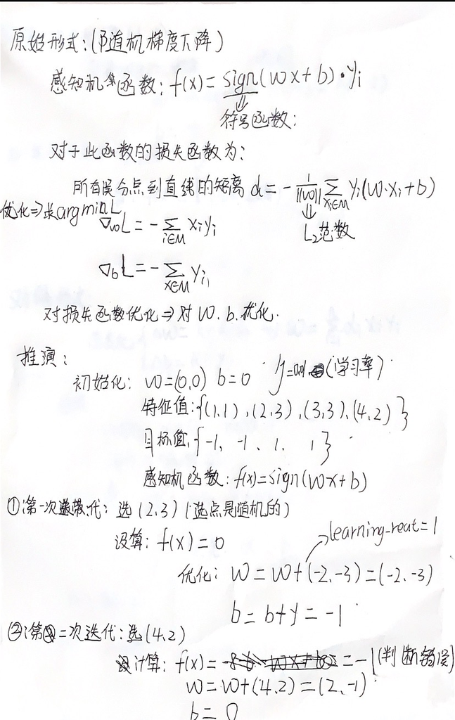

```python
from IPython.display import Image
Image(filename = 'E:/1.jpg', width=1000, height=60)
```

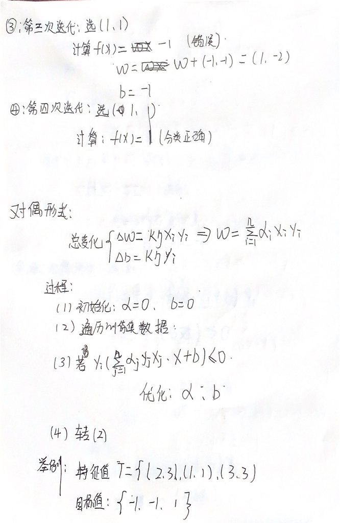

```python
 Image(filename = 'E:/2.jpg', width=1000, height=60)
```

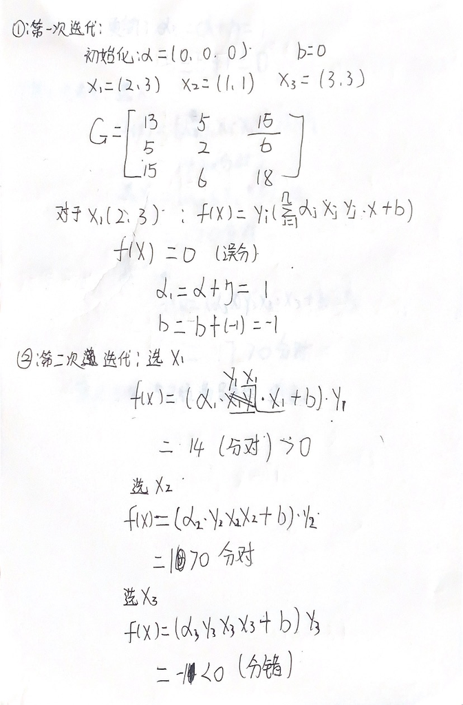

```python
Image(filename = 'E:/3.jpg', width=1000, height=60)
```

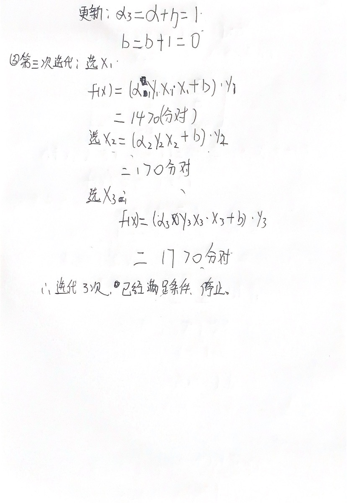

```python
Image(filename = 'E:/4.jpg', width=1000, height=60)
```

# 数形结合的方式解释感知机对偶形式的合理性

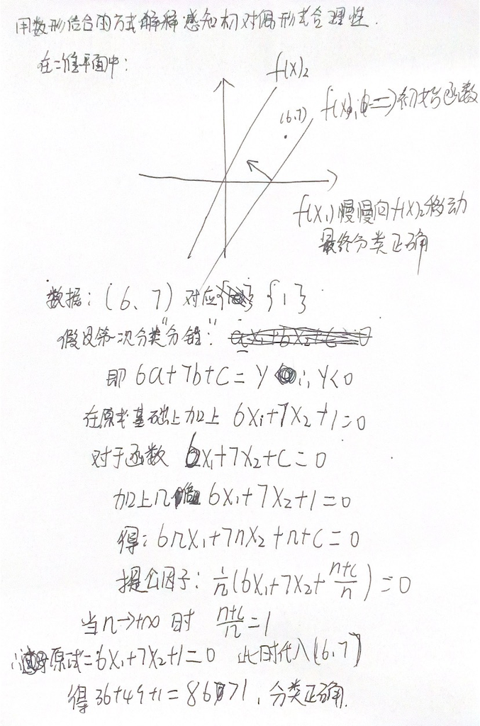

```python
Image(filename = 'E:/5.jpg', width=1000, height=60)
```

# LinearRegression例子

```python
# 这是参加的第一个比赛，当时用的就是LinearRegression
import pandas as pd
from sklearn.linear_model import LinearRegression
```

```python
train = pd.read_csv("E:/data/讯飞/环境空气质量评价挑战赛/初赛_训练集/保定2016年.csv")
test = pd.read_csv("E:\\data\\讯飞\\环境空气质量评价挑战赛\\初赛_测试集\\石家庄20160701-20170701.csv")
```

```python
train.shape, test.shape
```

```
((366, 10), (366, 9))
```

```python
train.head()
```

|  | 日期 | AQI | 质量等级 | PM2.5 | PM10 | SO2 | CO | NO2 | O3_8h | IPRC |
| --- | --- | --- | --- | --- | --- | --- | --- | --- | --- | --- |
| 0 | 2016/1/1 | 293 | 重度污染 | 243 | 324 | 122 | 6.1 | 149 | 12 | 2.088378 |
| 1 | 2016/1/2 | 430 | 严重污染 | 395 | 517 | 138 | 7.5 | 180 | 18 | 3.316942 |
| 2 | 2016/1/3 | 332 | 严重污染 | 282 | 405 | 72 | 6.3 | 130 | 10 | 2.516425 |
| 3 | 2016/1/4 | 204 | 重度污染 | 154 | 237 | 73 | 3.5 | 72 | 34 | 1.505693 |
| 4 | 2016/1/5 | 169 | 中度污染 | 128 | 186 | 99 | 3.2 | 66 | 39 | 1.210233 |

```python
def train_list(x):  # 提取特征
    train_list = []
    name = ["PM2.5", "PM10", "SO2", "CO", "NO2", "O3_8h"]
    for i in range(x.shape[0]):
        lista = []
        for j in name:
            lista.append(x.iloc[i, :]["{}".format(j)])
        train_list.append(lista)
    return train_list

x = train[["PM2.5", "PM10", "SO2", "CO", "NO2", "O3_8h"]]
y = train[["IPRC"]]
# 获取目标值
target = y["IPRC"].to_list()
# 获取样本
x_train = train_list(x)
# 选择算法，训练
liner = LinearRegression()
liner.fit(x_train, target)
```

```
LinearRegression()
```

```python
# 预测数据
y_pre = liner.predict(train_list(test))
tem = test["日期"].tolist()
res = pd.DataFrame()
res["date"] = tem
res["IPRC"] = y_pre
res
```

|  | date | IPRC |
| --- | --- | --- |
| 0 | 2016/7/1 | 0.380650 |
| 1 | 2016/7/2 | 0.477261 |
| 2 | 2016/7/3 | 0.384031 |
| 3 | 2016/7/4 | 0.311324 |
| 4 | 2016/7/5 | 0.390411 |
| ... | ... | ... |
| 361 | 2017/6/27 | 0.826413 |
| 362 | 2017/6/28 | 1.002322 |
| 363 | 2017/6/29 | 0.898804 |
| 364 | 2017/6/30 | 0.759407 |
| 365 | 2017/7/1 | 0.820251 |

366 rows × 2 columns

MSE: MSE （Mean Squared Error）叫做均方误差，是反映估计量与被估计量之间差异程度的一种度量。设t是根据子样确定的总体参数θ的一个估计量，(θ-t)2的数学期望，称为估计量t的均方误差。它等于σ2+b2，其中σ2与b分别是t的方差与偏倚|

RMSE: RMSE（Root Mean Squard Error）均方根误差，亦称标准误差，其定义为 ，i=1，2，3，…n。在有限测量次数中，均方根误差常用下式表示：√[∑di^2/n]=Re，式中：n为测量次数；di为一组测量值与真值的偏差。如果误差统计分布是正态分布，那么随机误差落在±σ以内的概率为68%。

MAE:平均绝对误差（Mean Absolute Deviation），又叫平均绝对离差，是所有单个观测值与算术平均值的偏差的绝对值的平均。平均绝对误差可以避免误差相互抵消的问题，因而可以准确反映实际预测误差的大小

R-Squared:R平方（R-squared）是反映业绩基准的变动对基金表现的影响，影响程度以 0～100 计。如果R平方值等于100，表示基金回报的变动完全由业绩基准的变动所致；若R平方值等于35，即35%的基金回报可归因于业绩基准的变动。简言之，R 平方值越低，由业绩基准变动导致的基金业绩的变动便越少。此外，R平方也可用来确定β系数或α系数的准确性。一般而言，基金的R平方值越高，其两个系数的准确性便越高。

```python
# https://www.jianshu.com/p/9ee85fdad150
```

# Numpy部分

```python
# 矩阵的转置
import numpy as np

a = np.arange(12).reshape(3,4)

print ('原数组：')
print (a)
print ('\n')

print ('转置数组：')
print (a.T)
```

```
原数组：
[[ 0  1  2  3]
 [ 4  5  6  7]
 [ 8  9 10 11]]


转置数组：
[[ 0  4  8]
 [ 1  5  9]
 [ 2  6 10]
 [ 3  7 11]]
```

```python
# matlib.empty() 函数返回一个新的矩阵,数据是随机的：numpy.matlib.empty(shape, dtype, order)
import numpy.matlib
import numpy as np

print (np.matlib.empty((2,2)))    # 随机的
```

```
[[0. 0.]
 [0. 0.]]
```

```python
# numpy.matlib.zeros() 函数创建一个以 0 填充的矩阵
import numpy.matlib
import numpy as np

print (np.matlib.zeros((2,2)))
```

```
[[0. 0.]
 [0. 0.]]
```

```python
# numpy.matlib.ones()函数创建一个以 1 填充的矩阵
import numpy.matlib
import numpy as np

print (np.matlib.ones((2,2)))
```

```
[[1. 1.]
 [1. 1.]]
```

```python
# numpy.dot() 对于两个一维的数组，计算的是这两个数组对应下标元素的乘积和(数学上称之为内积)；
# 对于二维数组，计算的是两个数组的矩阵乘积；
# 对于多维数组，它的通用计算公式如下，即结果数组中的每个元素都是：
#     数组a的最后一维上的所有元素与数组b的倒数第二位上的所有元素的乘积和： dot(a, b)[i,j,k,m] = sum(a[i,j,:] * b[k,:,m])。

import numpy.matlib
import numpy as np

a = np.array([[1,2],[3,4]])
b = np.array([[11,12],[13,14]])
print(np.dot(a,b))
```

```
[[37 40]
 [85 92]]
```

```python
# numpy.vdot() 函数是两个向量的点积。 如果第一个参数是复数，那么它的共轭复数会用于计算。 如果参数是多维数组，它会被展开
import numpy as np

a = np.array([[1,2],[3,4]])
b = np.array([[11,12],[13,14]])

# vdot 将数组展开计算内积
print (np.vdot(a,b))
```

```
130
```

```python
# numpy.linalg.det() 函数计算输入矩阵的行列式
import numpy as np
a = np.array([[1,2], [3,4]])

print (np.linalg.det(a))
```

```
-2.0000000000000004
```

```python
# numpy.savez() 函数将多个数组保存到以 npz 为扩展名的文件中
import numpy as np

a = np.array([[1,2,3],[4,5,6]])
b = np.arange(0, 1.0, 0.1)
c = np.sin(b)
# c 使用了关键字参数 sin_array
np.savez("runoob.npz", a, b, sin_array = c)
r = np.load("runoob.npz")
print(r.files) # 查看各个数组名称
print(r["arr_0"]) # 数组 a
print(r["arr_1"]) # 数组 b
print(r["sin_array"]) # 数组 c
```

```
['sin_array', 'arr_0', 'arr_1']
[[1 2 3]
 [4 5 6]]
[0.  0.1 0.2 0.3 0.4 0.5 0.6 0.7 0.8 0.9]
[0.         0.09983342 0.19866933 0.29552021 0.38941834 0.47942554
 0.56464247 0.64421769 0.71735609 0.78332691]
```

[output not shown]

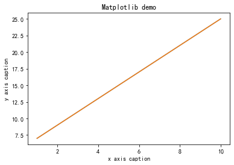

```python
import numpy as np
from matplotlib import pyplot as plt
# import matplotlib

# fname 为 你下载的字体库路径，注意 SourceHanSansSC-Bold.otf 字体的路径
# zhfont1 = matplotlib.font_manager.FontProperties(fname="SourceHanSansSC-Bold.otf")

x = np.arange(1,11)
y =  2  * x +  5

plt.title("Matplotlib demo")
plt.xlabel("x axis caption")
plt.ylabel("y axis caption")
plt.plot(x,y)

plt.plot(x,y)
```

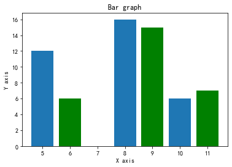

```python
# pyplot 子模块提供 bar() 函数来生成条形图。

# 以下实例生成两组 x 和 y 数组的条形图
from matplotlib import pyplot as plt
x =  [5,8,10]
y =  [12,16,6]
x2 =  [6,9,11]
y2 =  [6,15,7]
plt.bar(x, y, align =  'center')
plt.bar(x2, y2, color =  'g', align =  'center')
plt.title('Bar graph')
plt.ylabel('Y axis')
plt.xlabel('X axis')
plt.show()
```